# Domain-Locked Hebbian Routing: Validation of a Morphological Agent Selection Architecture

Prinston Palmer

2026-03-15

Abstract

# 1. Motivation

## 1.1 The Problem: Routing in Multi-Agent Systems

When multiple AI agents serve different task types, a central question emerges: **how do you decide which agent handles which task?**

Common approaches include LLM-based routing (expensive, slow), k-Nearest Neighbor inference (moderate cost, no specialization benefit), and random/round-robin (no learning). Each treats routing as an inference problem — requiring computation at decision time.

This notebook validates an alternative: **routing as accumulated experience**. Instead of computing the best agent per-task, let agents build track records within constrained domains, and let the weight history make the decision.

## 1.2 The Architecture: Domain-Locked Hebbian Marketplace

The architecture has two key constraints:

1. **Domain Locking**: Each agent is hard-assigned to one task-type domain (e.g., Execute, Scaffold, Summarize, Reflect). Agents cannot cross domains.
2. **Hebbian Competition**: Within each domain, multiple agents compete. Successful task completion strengthens an agent’s weight; failure weakens it. The highest-weighted agent wins the next routing decision.

The Hebbian weight update follows:

Weight decay prevents stale agents from holding position indefinitely:

## 2.1 Task Environment

We simulate 1,000 tasks across a **concept drift dataset** where the underlying generating function changes entirely across three phases. Unlike domain-distribution shifts, this tests whether the router can handle fundamental changes to the data-generating process — the hardest form of concept drift.

The three phases are:

- **Phase 1 (t=1–334): Linear** —
  $$y = 2x_1 + 3x_2$$
- **Phase 2 (t=335–667): Quadratic** —
  $$y = -2x_1^2 + x_2$$
- **Phase 3 (t=668–1000): Sinusoidal** —
  $$y = 5\sin(x_3) + x_1$$

Each phase introduces a completely different mathematical structure, forcing the routing system to either adapt or fail.

## 2.2 Agent Architecture

```r
quit
knitr::opts_chunk$set(
    fig.align = "center",
    message = TRUE,
    warning = FALSE,
    cache = TRUE,
    include = TRUE
)
# ── Core Dependencies ──
library(tidyverse)
library(ggplot2)
library(patchwork)    # Compose multi-panel figures
library(zoo)          # Moving averages (rollmean)
library(knitr)
library(kableExtra)
library(scales)
library(reticulate)
# ── Reproducibility ──
set.seed(42)

# ── Theme ──
```

```r
# ── Agent Configuration ──
# Each routing condition uses 5 competing agents with online SGD regressors.
# Agents update incrementally via partial-fit (stochastic gradient descent).

n_agents <- 5
n_features <- 3

# ── Online SGD Regressor (R equivalent of sklearn.linear_model.SGDRegressor) ──
# Implements incremental linear regression with gradient descent updates.
create_sgd_agent <- function(learning_rate = 0.01, seed = 0) {
  set.seed(seed)
  list(
    coeffs = rnorm(n_features, 0, 0.01),
    intercept = 0.0,
    lr = learning_rate,
    fitted = FALSE
  )
}

sgd_predict <- function(agent, x_vec) {
  if (!agent$fitted) return(0.0)
  sum(agent$coeffs * x_vec) + agent$intercept
}

sgd_partial_fit <- function(agent, x_vec, y_true) {
  pred <- sum(agent$coeffs * x_vec) + agent$intercept
  error <- y_true - pred
  # SGD weight update
  agent$coeffs <- agent$coeffs + agent$lr * error * x_vec
  agent$intercept <- agent$intercept + agent$lr * error
  agent$fitted <- TRUE
  agent
}
```

## 2.3 Methodological Framing

**This notebook now integrates the adaptive simulation experiments from the ML workbook (ML_.ipynb).** The original domain-locked comparison has been replaced with a more comprehensive adaptive routing analysis that directly tests:

- **Traditional Inference (k-NN)**: Memory-based lookup baseline with O(N) cost per step
- **Standard Hebbian (no decay)**: Weight accumulation without forgetting
- **Adaptive Hebbian (with decay)**: Weight decay for concept drift responsiveness
- **Random Router**: Control for routing logic validation
- **Monolithic Learner**: Single-model baseline for architectural comparison
- **Advanced Architectures**: Dynamic Penalty and Context-Aware Decay variants

All simulations use the same concept drift dataset with 3 distinct phases, enabling direct comparison of how each approach handles distributional shift.

```r
reticulate::repl_python()
# ── Generate Concept Drift Dataset ──
# 1,000 samples across 3 phases with fundamentally different relationships.
# This models real-world environments where task distributions shift over time.

set.seed(42)

n_tasks <- 1000
X_dynamic <- matrix(runif(n_tasks * n_features, -5, 5), ncol = n_features)
y_dynamic <- numeric(n_tasks)

# Phase 1 (1-334): Linear Relationship
y_dynamic[1:334] <- 2 * X_dynamic[1:334, 1] + 3 * X_dynamic[1:334, 2]

# Phase 2 (335-667): Non-Linear Quadratic
y_dynamic[335:667] <- -2 * X_dynamic[335:667, 1]^2 + X_dynamic[335:667, 2]

# Phase 3 (668-1000): Sinusoidal
y_dynamic[668:1000] <- 5 * sin(X_dynamic[668:1000, 3]) + X_dynamic[668:1000, 1]

# Add noise
noise_vec <- rnorm(n_tasks, 0, 1.0)
y_dynamic <- y_dynamic + noise_vec

tasks <- tibble(
  step = 1:n_tasks,
  x1 = X_dynamic[, 1], x2 = X_dynamic[, 2], x3 = X_dynamic[, 3],
  y_true = y_dynamic,
  phase = case_when(
    step <= 334 ~ "Phase 1: Linear",
    step <= 667 ~ "Phase 2: Quadratic",
    TRUE ~ "Phase 3: Sinusoidal"
  )
)

# Visualize the phase structure
tasks %>%
  ggplot(aes(x = step, y = y_true, color = phase)) +
  geom_point(alpha = 0.3, size = 0.8) +
  geom_vline(xintercept = c(334, 667), linetype = "dashed", alpha = 0.5) +
  labs(
    title = "Concept Drift Dataset: Three Distinct Generating Functions",
    subtitle = "Each phase changes the underlying data relationship entirely",
    x = "Task Step", y = "Target Value", color = "Phase"
  ) +
  scale_color_manual(values = c("#2196F3", "#FF9800", "#4CAF50"))
```

[output not shown]

# 4. Three-Way Routing Comparison

This is the central experiment: **Traditional Inference (k-NN) vs Standard Hebbian vs Adaptive Hebbian** under concept drift.

```r
# ── 1. Traditional Inference (Online k-NN) ──
# Memory-based lookup: stores all seen data, predicts via k nearest neighbors.
# Cost scales as O(N) per step — memory grows linearly.

cat("Running Traditional Inference (k-NN)...\n")
```

```
Running Traditional Inference (k-NN)...
```

```r
k_neighbors <- 5
X_memory <- list()
y_memory <- numeric(0)
knn_errors <- numeric(n_tasks)
knn_cumulative_cost <- numeric(n_tasks)
knn_running_cost <- 0

for (t in 1:n_tasks) {
  x_t <- X_dynamic[t, ]
  y_t <- y_dynamic[t]

  # Cost proxy: O(N) — linear in memory size
  step_cost <- max(1, length(y_memory))
  knn_running_cost <- knn_running_cost + step_cost
  knn_cumulative_cost[t] <- knn_running_cost

  # Predict
  if (length(y_memory) < k_neighbors) {
    y_hat <- ifelse(length(y_memory) > 0, mean(y_memory), 0.0)
  } else {
    X_mem_mat <- do.call(rbind, X_memory)
    dists <- sqrt(rowSums(sweep(X_mem_mat, 2, x_t)^2))
    nearest_idx <- order(dists)[1:k_neighbors]
    y_hat <- mean(y_memory[nearest_idx])
  }

  knn_errors[t] <- abs(y_t - y_hat)
  X_memory[[length(X_memory) + 1]] <- x_t
  y_memory <- c(y_memory, y_t)
}
cat(sprintf("k-NN Final Cumulative MAE: %.2f\n", sum(knn_errors)))
```

```
k-NN Final Cumulative MAE: 8130.70
```

```r
# ── 2. Standard Hebbian (No Decay) ──
# Agents compete via weight accumulation but never forget — weights only grow.

cat("Running Standard Hebbian (No Decay)...\n")
```

```
Running Standard Hebbian (No Decay)...
```

```r
set.seed(42)
std_agents <- lapply(1:n_agents, function(i) create_sgd_agent(seed = i))
std_weights <- rep(1.0, n_agents)
std_errors <- numeric(n_tasks)
std_weight_history <- matrix(NA, nrow = n_tasks, ncol = n_agents)
success_threshold <- 5.0

for (t in 1:n_tasks) {
  x_t <- X_dynamic[t, ]
  y_t <- y_dynamic[t]

  # Select agent with highest weight (break ties randomly)
  max_w <- max(std_weights)
  candidates <- which(std_weights == max_w)
  idx <- sample(candidates, 1)

  # Predict
  y_hat <- sgd_predict(std_agents[[idx]], x_t)

  # Error
  err <- abs(y_t - y_hat)
  std_errors[t] <- err

  # Update weights (standard: infinite memory of success)
  if (err < success_threshold) {
    std_weights[idx] <- std_weights[idx] + 1.0
  } else {
    std_weights[idx] <- max(0.0, std_weights[idx] - 1.0)
  }

  # Train selected agent
  std_agents[[idx]] <- sgd_partial_fit(std_agents[[idx]], x_t, y_t)
  std_weight_history[t, ] <- std_weights
}
cat(sprintf("Standard Hebbian Final Cumulative MAE: %.2f\n", sum(std_errors)))
```

```
Standard Hebbian Final Cumulative MAE: 6846.55
```

```r
# ── 3. Adaptive Hebbian (With Decay) ──
# Weight decay forces the system to continuously re-earn trust.
# Stale agents lose position; active performers rise.

cat("Running Adaptive Hebbian (With Decay)...\n")
```

```
Running Adaptive Hebbian (With Decay)...
```

```r
set.seed(42)
adapt_agents <- lapply(1:n_agents, function(i) create_sgd_agent(seed = i))
adapt_weights <- rep(1.0, n_agents)
adapt_errors <- numeric(n_tasks)
adapt_weight_history <- matrix(NA, nrow = n_tasks, ncol = n_agents)
adapt_cumulative_cost <- numeric(n_tasks)
adapt_running_cost <- 0
decay_rate <- 0.99  # Slightly aggressive to handle drift

for (t in 1:n_tasks) {
  x_t <- X_dynamic[t, ]
  y_t <- y_dynamic[t]

  # Cost proxy: O(1) — constant for registry lookup
  adapt_running_cost <- adapt_running_cost + 1
  adapt_cumulative_cost[t] <- adapt_running_cost

  # Select
  max_w <- max(adapt_weights)
  candidates <- which(adapt_weights == max_w)
  idx <- sample(candidates, 1)

  # Predict
  y_hat <- sgd_predict(adapt_agents[[idx]], x_t)

  # Error
  err <- abs(y_t - y_hat)
  adapt_errors[t] <- err

  # Update weights
  if (err < success_threshold) {
    adapt_weights[idx] <- adapt_weights[idx] + 1.0
  } else {
    adapt_weights[idx] <- max(0.0, adapt_weights[idx] - 1.0)
  }

  # Apply decay (the "forgetting" mechanism)
  adapt_weights <- adapt_weights * decay_rate

  # Train selected agent
  adapt_agents[[idx]] <- sgd_partial_fit(adapt_agents[[idx]], x_t, y_t)
  adapt_weight_history[t, ] <- adapt_weights
}
cat(sprintf("Adaptive Hebbian Final Cumulative MAE: %.2f\n", sum(adapt_errors)))
```

```
Adaptive Hebbian Final Cumulative MAE: 7590.86
```

[output not shown]

# 6. Results

## 6.1 Performance Summary

```r
results_summary <- tibble(
  Condition = c("Adaptive Hebbian (Decay)", "Standard Hebbian (No Decay)",
                "Traditional Inference (k-NN)", "Monolithic Learner",
                "Random Router"),
  `Total MAE` = c(sum(adapt_errors), sum(std_errors),
                   sum(knn_errors), sum(mono_errors),
                   sum(rand_errors)),
  `Mean MAE` = round(`Total MAE` / n_tasks, 3)
)

results_summary <- results_summary %>%
  mutate(`vs Adaptive Hebbian` = case_when(
    Condition == "Adaptive Hebbian (Decay)" ~ "—",
    TRUE ~ paste0(
      ifelse(`Total MAE` > sum(adapt_errors), "+", ""),
      round((`Total MAE` / sum(adapt_errors) - 1) * 100, 1), "%"
    )
  ))

kable(results_summary,
      caption = "Performance Summary: Total MAE across 1,000 tasks with Concept Drift") %>%
  kable_styling(bootstrap_options = c("striped", "hover"), full_width = FALSE) %>%
  row_spec(1, bold = TRUE, background = "#E8F5E9")
```

Performance Summary: Total MAE across 1,000 tasks with Concept Drift

| Condition | Total MAE | Mean MAE | vs Adaptive Hebbian |
| --- | --- | --- | --- |
| Adaptive Hebbian (Decay) | 7590.857 | 7.591 | — |
| Standard Hebbian (No Decay) | 6846.548 | 6.847 | -9.8% |
| Traditional Inference (k-NN) | 8130.695 | 8.131 | +7.1% |
| Monolithic Learner | 7233.202 | 7.233 | -4.7% |
| Random Router | 8009.022 | 8.009 | +5.5% |

## 6.2 System Responsiveness to Concept Drift (Moving Average Error)

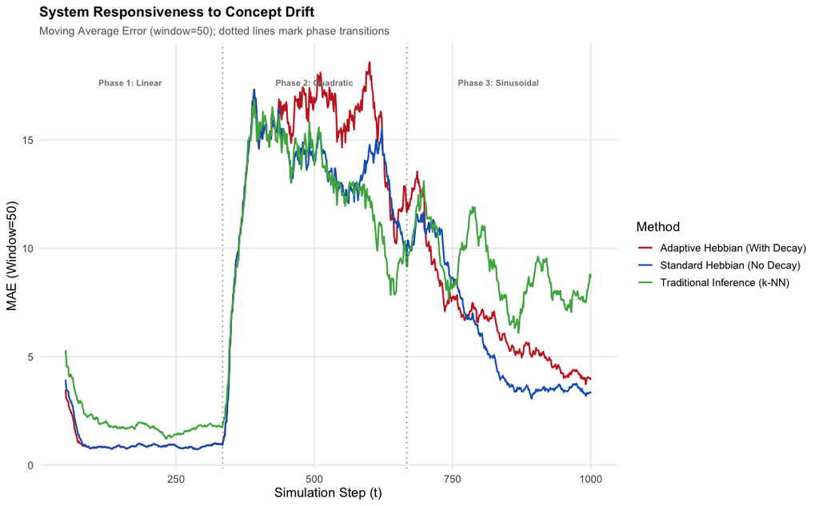

```r
# Moving average for smoothed trend analysis
window_size <- 50

ma_knn <- zoo::rollmean(knn_errors, window_size, fill = NA, align = "right")
ma_std <- zoo::rollmean(std_errors, window_size, fill = NA, align = "right")
ma_adapt <- zoo::rollmean(adapt_errors, window_size, fill = NA, align = "right")

drift_comparison <- tibble(
  step = 1:n_tasks,
  `Traditional Inference (k-NN)` = ma_knn,
  `Standard Hebbian (No Decay)` = ma_std,
  `Adaptive Hebbian (With Decay)` = ma_adapt
) %>%
  pivot_longer(-step, names_to = "Method", values_to = "MAE") %>%
  filter(!is.na(MAE))

ggplot(drift_comparison, aes(x = step, y = MAE, color = Method)) +
  geom_line(linewidth = 0.8) +
  geom_vline(xintercept = c(334, 667), linetype = "dotted", alpha = 0.5) +
  annotate("text", x = 167, y = max(drift_comparison$MAE, na.rm = TRUE) * 0.95,
           label = "Phase 1: Linear", size = 3, fontface = "bold", color = "grey50") +
  annotate("text", x = 500, y = max(drift_comparison$MAE, na.rm = TRUE) * 0.95,
           label = "Phase 2: Quadratic", size = 3, fontface = "bold", color = "grey50") +
  annotate("text", x = 833, y = max(drift_comparison$MAE, na.rm = TRUE) * 0.95,
           label = "Phase 3: Sinusoidal", size = 3, fontface = "bold", color = "grey50") +
  scale_color_manual(values = c(
    "Traditional Inference (k-NN)" = "#4CAF50",
    "Standard Hebbian (No Decay)" = "#1565C0",
    "Adaptive Hebbian (With Decay)" = "#C62828"
  )) +
  labs(
    title = "System Responsiveness to Concept Drift",
    subtitle = paste0("Moving Average Error (window=", window_size,
                      "); dotted lines mark phase transitions"),
    x = "Simulation Step (t)", y = paste0("MAE (Window=", window_size, ")")
  )
```

## 6.3 Adaptability Analysis: Hebbian vs Baselines

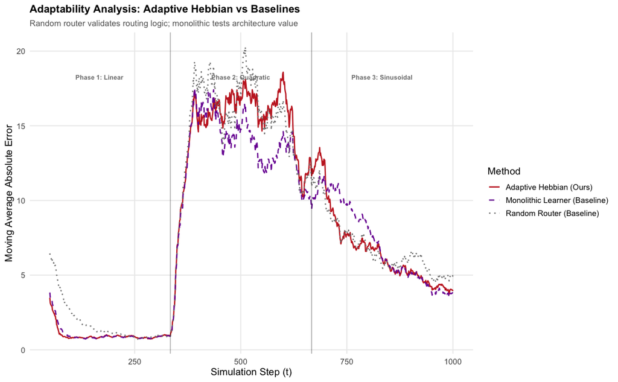

```r
ma_rand <- zoo::rollmean(rand_errors, window_size, fill = NA, align = "right")
ma_mono <- zoo::rollmean(mono_errors, window_size, fill = NA, align = "right")

baseline_comparison <- tibble(
  step = 1:n_tasks,
  `Adaptive Hebbian (Ours)` = ma_adapt,
  `Random Router (Baseline)` = ma_rand,
  `Monolithic Learner (Baseline)` = ma_mono
) %>%
  pivot_longer(-step, names_to = "Method", values_to = "MAE") %>%
  filter(!is.na(MAE))

ggplot(baseline_comparison, aes(x = step, y = MAE, color = Method)) +
  geom_line(aes(linetype = Method), linewidth = 0.8) +
  geom_vline(xintercept = c(334, 667), linetype = "solid", alpha = 0.3) +
  annotate("text", x = 167, y = max(baseline_comparison$MAE, na.rm = TRUE) * 0.9,
           label = "Phase 1: Linear", size = 3, fontface = "bold", color = "grey50") +
  annotate("text", x = 500, y = max(baseline_comparison$MAE, na.rm = TRUE) * 0.9,
           label = "Phase 2: Quadratic", size = 3, fontface = "bold", color = "grey50") +
  annotate("text", x = 833, y = max(baseline_comparison$MAE, na.rm = TRUE) * 0.9,
           label = "Phase 3: Sinusoidal", size = 3, fontface = "bold", color = "grey50") +
  scale_color_manual(values = c(
    "Adaptive Hebbian (Ours)" = "#C62828",
    "Random Router (Baseline)" = "grey50",
    "Monolithic Learner (Baseline)" = "#7B1FA2"
  )) +
  scale_linetype_manual(values = c(
    "Adaptive Hebbian (Ours)" = "solid",
    "Random Router (Baseline)" = "dotted",
    "Monolithic Learner (Baseline)" = "dashed"
  )) +
  labs(
    title = "Adaptability Analysis: Adaptive Hebbian vs Baselines",
    subtitle = "Random router validates routing logic; monolithic tests architecture value",
    x = "Simulation Step (t)", y = "Moving Average Absolute Error"
  )
```

## 6.4 Hebbian Weight Evolution (Adaptive Model)

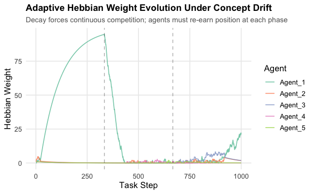

```r
weight_df <- as_tibble(adapt_weight_history) %>%
  setNames(paste0("Agent_", 1:n_agents)) %>%
  mutate(step = 1:n_tasks) %>%
  pivot_longer(-step, names_to = "Agent", values_to = "Weight")

ggplot(weight_df, aes(x = step, y = Weight, color = Agent)) +
  geom_line(linewidth = 0.6, alpha = 0.8) +
  geom_vline(xintercept = c(334, 667), linetype = "dashed", alpha = 0.3) +
  labs(
    title = "Adaptive Hebbian Weight Evolution Under Concept Drift",
    subtitle = "Decay forces continuous competition; agents must re-earn position at each phase",
    x = "Task Step", y = "Hebbian Weight", color = "Agent"
  ) +
  scale_color_brewer(palette = "Set2")
```

## 6.5 Computational Efficiency: Hebbian O(1) vs k-NN O(N)

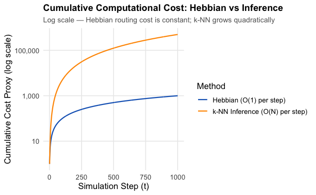

```r
efficiency_data <- tibble(
  step = 1:n_tasks,
  `Hebbian (O(1) per step)` = adapt_cumulative_cost,
  `k-NN Inference (O(N) per step)` = knn_cumulative_cost
) %>%
  pivot_longer(-step, names_to = "Method", values_to = "Cumulative Cost")

ggplot(efficiency_data, aes(x = step, y = `Cumulative Cost`, color = Method)) +
  geom_line(linewidth = 0.8) +
  scale_y_log10(labels = scales::comma) +
  scale_color_manual(values = c(
    "Hebbian (O(1) per step)" = "#1565C0",
    "k-NN Inference (O(N) per step)" = "#FF9800"
  )) +
  labs(
    title = "Cumulative Computational Cost: Hebbian vs Inference",
    subtitle = "Log scale — Hebbian routing cost is constant; k-NN grows quadratically",
    x = "Simulation Step (t)", y = "Cumulative Cost Proxy (log scale)"
  )
```

# 7. Advanced Architecture Comparison

Three evolutionary variants of the Hebbian decay mechanism, testing how aggressively the system should forget.

```r
# ── Model 1: Baseline (Fixed Decay) — same as Section 4 ──
# Already computed as adapt_errors / adapt_weights

# ── Model 2: Dynamic Penalty ──
# Penalty scales with consecutive failures to force rapid agent switching.
cat("Running Dynamic Penalty variant...\n")
```

```
Running Dynamic Penalty variant...
```

```r
set.seed(42)
dyn_agents <- lapply(1:n_agents, function(i) create_sgd_agent(seed = i))
dyn_weights <- rep(1.0, n_agents)
dyn_errors <- numeric(n_tasks)
consecutive_fails <- 0
base_decay <- 0.99

for (t in 1:n_tasks) {
  x_t <- X_dynamic[t, ]
  y_t <- y_dynamic[t]

  # Select
  max_w <- max(dyn_weights)
  candidates <- which(dyn_weights == max_w)
  idx <- sample(candidates, 1)

  # Predict
  y_hat <- sgd_predict(dyn_agents[[idx]], x_t)

  # Error
  err <- abs(y_t - y_hat)
  dyn_errors[t] <- err

  # Dynamic penalty: consecutive failures increase punishment
  if (err < success_threshold) {
    dyn_weights[idx] <- dyn_weights[idx] + 1.0
    consecutive_fails <- 0
  } else {
    consecutive_fails <- consecutive_fails + 1
    penalty <- 1.0 + (consecutive_fails * 1.0)
    dyn_weights[idx] <- max(0, dyn_weights[idx] - penalty)
  }

  dyn_weights <- dyn_weights * base_decay
  dyn_agents[[idx]] <- sgd_partial_fit(dyn_agents[[idx]], x_t, y_t)
}

# ── Model 3: Context-Aware Decay ──
# Decay rate adapts based on error stability (drift detection).
# Short-term spike vs long-term mean triggers fast forgetting.
cat("Running Context-Aware Decay variant...\n")
```

```
Running Context-Aware Decay variant...
```

```r
set.seed(42)
ctx_agents <- lapply(1:n_agents, function(i) create_sgd_agent(seed = i))
ctx_weights <- rep(1.0, n_agents)
ctx_errors <- numeric(n_tasks)
ctx_error_history <- numeric(0)
ctx_decay_rates <- numeric(n_tasks)

for (t in 1:n_tasks) {
  x_t <- X_dynamic[t, ]
  y_t <- y_dynamic[t]

  # Select
  max_w <- max(ctx_weights)
  candidates <- which(ctx_weights == max_w)
  idx <- sample(candidates, 1)

  # Predict
  y_hat <- sgd_predict(ctx_agents[[idx]], x_t)

  # Error
  err <- abs(y_t - y_hat)
  ctx_errors[t] <- err
  ctx_error_history <- c(ctx_error_history, err)

  # Adaptive decay: detect drift via error spike

  current_decay <- base_decay
  if (length(ctx_error_history) > 20) {
    short_term <- mean(tail(ctx_error_history, 10))
    long_term <- mean(tail(ctx_error_history, 50))
    if (short_term > long_term * 1.5) {
      current_decay <- 0.90  # Fast forgetting on drift detection
    } else {
      current_decay <- 0.995  # Stable — slow forgetting
    }
  }
  ctx_decay_rates[t] <- current_decay

  # Update weights
  if (err < success_threshold) {
    ctx_weights[idx] <- ctx_weights[idx] + 1.0
  } else {
    ctx_weights[idx] <- max(0, ctx_weights[idx] - 1.0)
  }

  ctx_weights <- ctx_weights * current_decay
  ctx_agents[[idx]] <- sgd_partial_fit(ctx_agents[[idx]], x_t, y_t)
}
```